# Final Project

Owen Braglio

2022-12-02

# Report

### Research Question:

What is the relationship between a baseball team’s runs scored, runs allowed, and their win rate for that season?

We wanted to find if there was a significant link between the runs scored by a team in a season, and their win rate. The initial hypothesis is yes of course, it should be a direct relationship, but factors like blowout games and close defeats may skew the numbers and make them less accurate than initially presumed.

### Data Source

We got both of our data sources from the MLB’s website as they have collected all relevant data into a couple tables for each Baseball League. As all teams were gather from the same source it also ensured consistency between the numbers reported.

### Data Focus

We’ll be focusing on Win Rate, Runs Scored and Runs Allowed to determine if there is a significant like between these factors and if a team made it to playoffs or not that season.

# Visualizations

## All League Teams chart

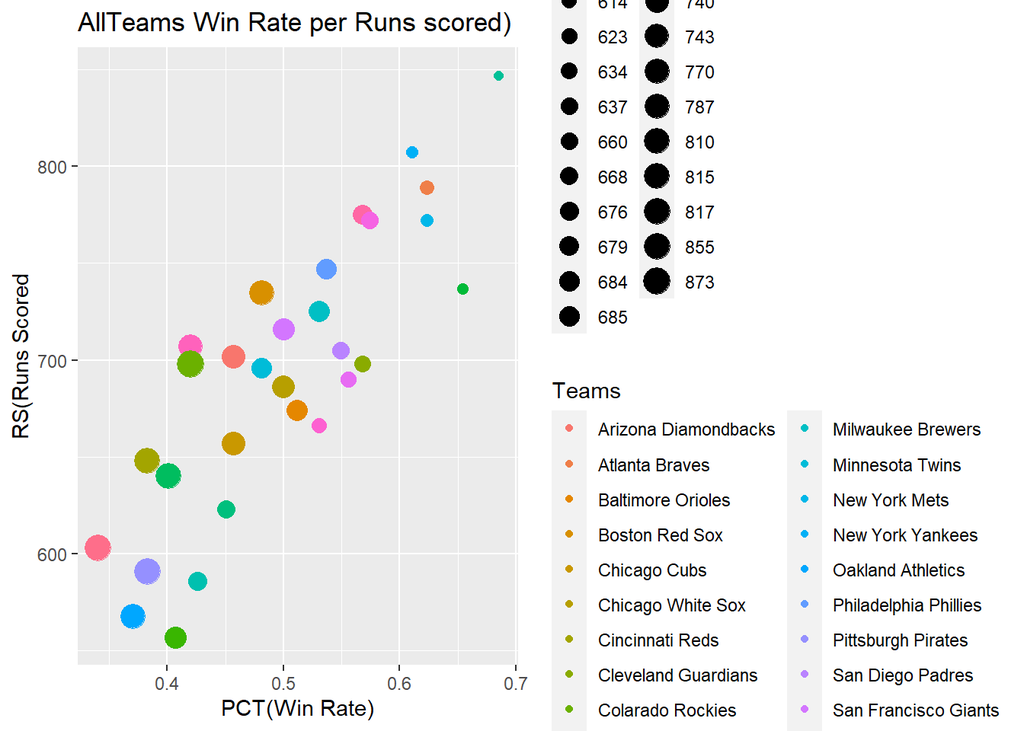

As can be seen in the visualization, the overall trend is the greater the runs scored the higher the win percentage. Small variances can be seen where teams did not conform to a direct relationship between the two. The overall trend is inherent as the team with more runs wins the game but, as can be seen by the size difference of the points, this is not the only direct relationship. The amount of runs allowed has a direct inverse relationship with the win percentage so it can be extrapolated that the game is just as much about preventing the other team from scoring. A balance must be maintained, though, as can be seen from teams like the Minnesota twins only allowing 684 runs, much better than many teams above them, but still losing because they failed to score runs themselves.

## National League Teams chart

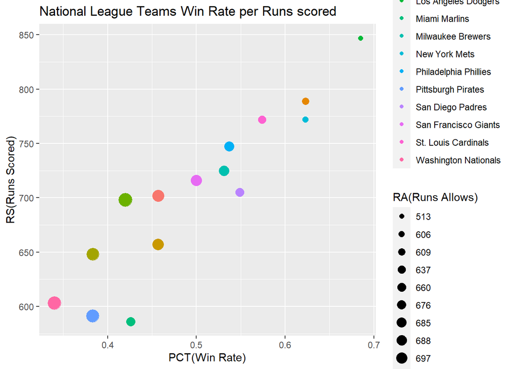

This graph is the greatest example of the direct relationship between the factors of Runs Scored and Win Rate. As the data lines up, it gives an almost linear line from the Washington Nationals to the Los Angeles Dodgers showing the higher the runs scored over a season, the more games won in it.

## American League Teams chart

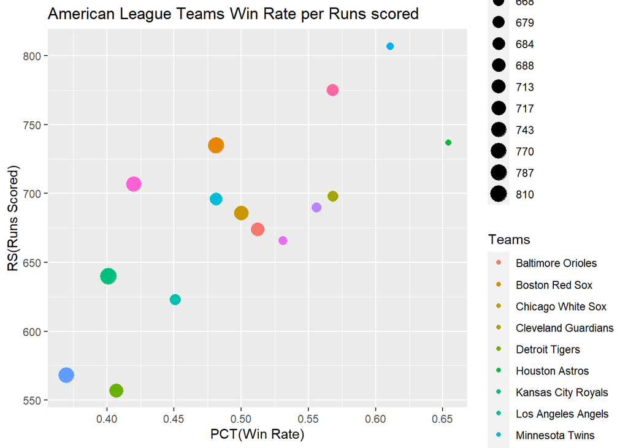

This graph is nothing like a clean line but shows the inverse relationship of Runs Allowed and Win Rate. As we move along the x axis it can be observed, with some outliers, that the size of each point, or the Runs Allowed, shrinks.

## Play off League Teams chart

[figure not shown]

As we move into the playoff teams, we see the best of the best this season and a reinforcing of the trends already observed previously. As the data progresses up, the win rate increases and as the win rate increases the size (runs allowed) decreases.

## National Play off Teams chart

[figure not shown]

## American Play off Teams chart

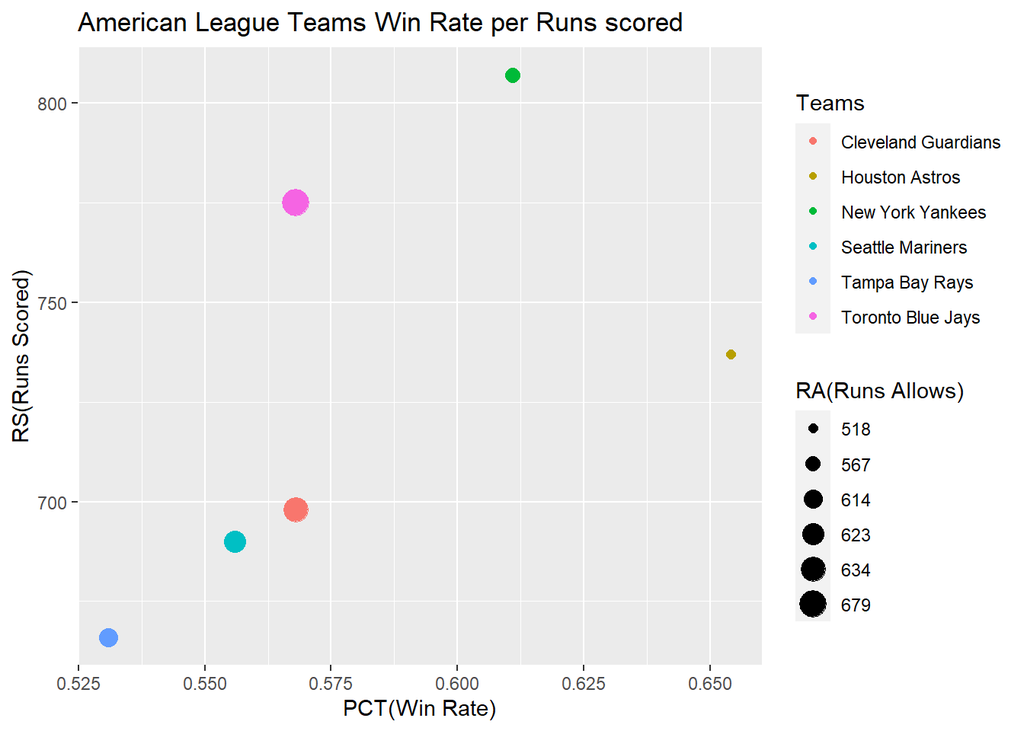